# Microbial Competition and Tree Functional Plasticity

Replicating and Extending Jiang et al. (Nature, 2024)

Author

Gia Trieu Pham; Ani Ugrelidze; Oishanu Dutta; Muhammad Hasher Naveed

Published

December 16, 2025

**Reference:**  
*Jiang M, Crous KY, Carrillo Y, et al. Microbial competition for phosphorus limits the CO2 response of a mature forest. Nature. 2024;630(8017):660-665. doi:10.1038/s41586-024-07491-0*

# 1 Introduction

## 1.1 Scientific Context

Elevated atmospheric CO2 (eCO2) typically stimulates plant growth. . However, in the mature Eucalyptus forest of the EucFACE experiment, biomass growth has remained stagnant. Jiang et al. (2024) propose the “Microbial Pre-emption Hypothesis”: soil microbes aggressively compete for scarce phosphorus (P), creating a nutrient bottleneck that prevents trees from utilizing the extra carbon.

We replicate and extend **Jiang et al. (2024)**, investigating “Microbial Pre-emption” at the EucFACE experiment. We test if microbes lock away Phosphorus (P), causing biomass stagnation, and if trees respond via functional plasticity.

## 1.2 Objectives

1. **The Lockout:** Microbial P pools > Available Soil P pools.
2. **Stagnation:** No increase in wood biomass under eCO2.
3. **Adaptation:** Trees shift allocation to roots (Foraging) or increase P-use efficiency (PUE).

# 2 Materials & Methods

**Data Structure:**

1. **Pools (Inventory):** Soil Phosphate (0-30cm), Microbial Phosphorus (0-30cm), Wood Carbon (Stem biomass).
2. **Fluxes (Rates):** Gross Primary Production (GPP) and Total Litter Phosphorus Return (Leaf + Twig + Bark + Seed).

**Statistical Analysis:**  
We performed data cleaning and aggregation in R (v4.3). We used **Linear Mixed-Effects Models (LMM)** via the lme4 package to test for treatment effects, using **Ring** as a random intercept to account for the spatial nesting of the experimental design *(`Variable∼Treatment×Year+(1∣Ring)).`*

```r
# --- 1. ROBUST DATA LOADER ---
load_data <- function(filename, val_col_pattern, type = "pool") {
  path <- here("EucFACE_P_Analysis/data", filename)
  if(!file.exists(path)) path <- here("data", filename)
  if(!file.exists(path)) return(NULL)

  df <- read_csv(path, show_col_types = FALSE)
  val_col <- names(df)[grepl(val_col_pattern, names(df), ignore.case = TRUE)][1]

  clean_df <- df %>%
    mutate(Date = parse_date_time(Date, orders = c("ymd", "dmy", "mdy")),
           Year = year(Date)) %>%
    filter(!is.na(Date)) %>%
    rename(Value = all_of(val_col))

  if (type == "pool") {
    out <- clean_df %>% group_by(Year, Ring) %>% summarise(Val = mean(Value, na.rm=TRUE), .groups="drop")
  } else if (type == "sum_depth") {
    out <- clean_df %>%
      filter(Depth %in% c("0_10", "10_30")) %>%
      group_by(Date, Ring) %>% summarise(DailySum = sum(Value), .groups="drop") %>%
      mutate(Year = year(Date)) %>%
      group_by(Year, Ring) %>% summarise(Val = mean(DailySum, na.rm=TRUE), .groups="drop")
  } else if (type == "flux") {
    out <- clean_df %>% group_by(Year, Ring) %>% summarise(Val = mean(Value, na.rm=TRUE)*365/1000, .groups="drop")
  }
  return(out)
}

# --- 2. EXECUTE LOADING ---
soil_p  <- load_data("soil_phosphate_pool.csv", "phosphate", type="sum_depth") %>% rename(Soil_P = Val)
micro_p <- load_data("microbial_p_pool.csv", "microbial", type="sum_depth") %>% rename(Micro_P = Val)
wood_c  <- load_data("wood_c_pool.csv", "wood", type="pool") %>% rename(Wood_C = Val)
root_c  <- load_data("fineroot_c_pool.csv", "fineroot", type="pool") %>% rename(Root_C = Val)
gpp     <- load_data("overstorey_gpp_flux.csv", "GPP", type="pool") %>% rename(GPP = Val)

litter_files <- c("leaflitter_p_flux.csv", "twiglitter_p_flux.csv", "bark_litter_p_flux.csv", "seed_litter_p_flux.csv")
litter_list  <- lapply(litter_files, function(f) load_data(f, "flux|mg", type="flux"))
litter_p <- bind_rows(litter_list) %>%
  group_by(Year, Ring) %>%
  summarise(Total_P_Lost = sum(Val, na.rm=TRUE), .groups="drop")

# --- 3. MASTER MERGE ---
df_list <- list(wood_c, root_c, gpp, litter_p, soil_p, micro_p)
df <- df_list %>%
  reduce(full_join, by = c("Year", "Ring")) %>%
  mutate(Trt = get_trt(Ring), Ring = factor(Ring)) %>%
  filter(Year >= 2013 & Year <= 2016) %>%
  mutate(PUE = GPP / Total_P_Lost, Root_Shoot_Ratio = Root_C / Wood_C)
```

# 3 Results: Replication

## 3.1 The Phosphorus Inventory

We compared the three main Phosphorus compartments: Available Soil P, Microbial P and Tree P Return (Litter Flux).

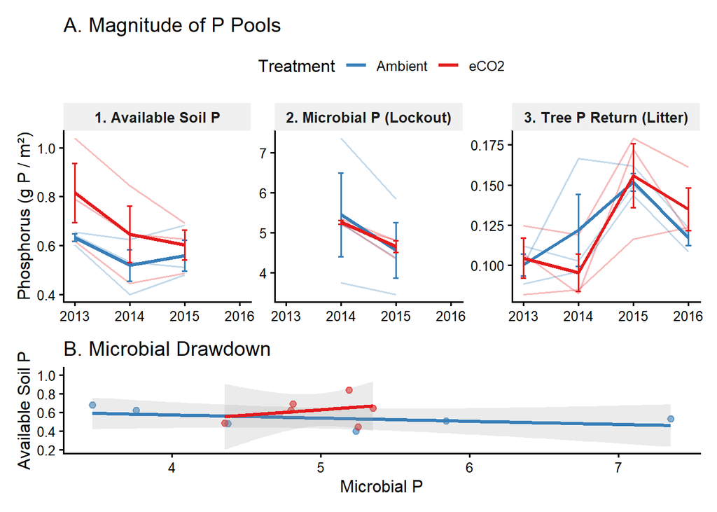

```r
# --- 1. PREPARE DATA ---
# We add "Total_P_Lost" (Litter) as a proxy for Tree P cycling
df_long_p <- df %>%
  select(Year, Ring, Trt, Soil_P, Micro_P, Total_P_Lost) %>%
  pivot_longer(cols = c(Soil_P, Micro_P, Total_P_Lost), names_to = "Type", values_to = "Val") %>%
  mutate(Type = recode(Type,
                       "Soil_P" = "1. Available Soil P",
                       "Micro_P" = "2. Microbial P (Lockout)",
                       "Total_P_Lost" = "3. Tree P Return (Litter)")) %>%
  drop_na(Val)

# --- 2. PLOT A: TIME SERIES ---
plot_a <- ggplot(df_long_p, aes(x = Year, y = Val, color = Trt)) +
  geom_line(aes(group = Ring), alpha = 0.3, linewidth = 0.6) +
  stat_summary(fun = mean, geom = "line", linewidth = 1.2) +
  stat_summary(fun.data = mean_se, geom = "errorbar", width = 0.1) +
  facet_wrap(~Type, scales = "free_y", nrow = 1) +
  scale_color_manual(name = "Treatment", values = cols) +
  scale_x_continuous(breaks = c(2013, 2014, 2015, 2016)) +
  labs(y = "Phosphorus (g P / m²)", x = NULL, title = "A. Magnitude of P Pools") +
  theme(legend.position = "top",
        strip.background = element_rect(fill = "#f0f0f0", color = NA),
        strip.text = element_text(face = "bold", size = 10))

# --- 3. PLOT B: CORRELATION (RELATION) ---
# Is there a trade-off? As Microbes go UP, does Soil P go DOWN?
plot_b <- ggplot(df, aes(x = Micro_P, y = Soil_P, color = Trt)) +
  geom_point(alpha = 0.6, size = 2) +
  geom_smooth(method = "lm", se = TRUE, alpha = 0.2) +
  scale_color_manual(name = "Treatment", values = cols) +
  labs(y = "Available Soil P", x = "Microbial P", title = "B. Microbial Drawdown") +
  theme(legend.position = "none")

# Combine plots using patchwork
combined_plot <- plot_a / plot_b + plot_layout(heights = c(2, 1))
print(combined_plot)
# Export the graphs for presentation
ggsave(here("EucFACE_P_Analysis/output", "Fig1_Phosphorus_Budget.png"),
       plot = combined_plot, width = 10, height = 7, dpi = 300)
```

```r
m_pool <- lmer(Val ~ Type * Trt + (1|Ring), data = df_long_p)
print_stats(m_pool, "Model: Value ~ Compartment * Treatment")
```

Table 1: ANOVA: Comparison of Ecosystem P Compartments.

Model: Value ~ Compartment * Treatment

|  | Sum Sq | Mean Sq | NumDF | DenDF | F-Statistic | P-Value | Sig |
| --- | --- | --- | --- | --- | --- | --- | --- |
| Type | 203.77 | 101.88 | 2 | 44.0 | 467.38 | < 0.001 | * |
| Trt | 0.00 | 0.00 | 1 | 4.3 | 0.01 | 0.910 |  |
| Type:Trt | 0.06 | 0.03 | 2 | 44.0 | 0.13 | 0.878 |  |

Note:  
* Indicates statistical significance (P < 0.05).

**Observation:** As shown in Figure 1 **(Panel A)**, the Microbial P pool (~5.0 g/m²) is approximately one order of magnitude larger than the Available Soil P pool (~0.5 g/m²) or the Tree P Return. The statistical analysis in Table 1 confirms that Type is the dominant factor explaining variance (P<0.001).

## 3.2 The Consequence: Biomass Stagnation

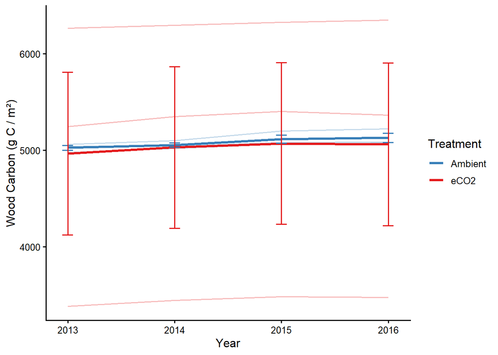

Figure 2: Wood Biomass Trajectory. Despite elevated CO2, the red line (eCO2) does not diverge from the blue line (Ambient).

```r
ggplot(df, aes(x=Year, y=Wood_C, color=Trt)) +
  geom_line(aes(group = Ring), alpha = 0.3, linewidth = 0.6) +
  stat_summary(fun=mean, geom="line", linewidth=1.2) +
  stat_summary(fun.data=mean_se, geom="errorbar", width=0.1) +
  scale_color_manual(name="Treatment", values=cols) +
  scale_x_continuous(breaks=2013:2016) +
  labs(y="Wood Carbon (g C / m²)")

ggsave(here("EucFACE_P_Analysis/output", "Fig2_Biomass_Stagnation.png"),
       width = 8, height = 5, dpi = 300)
```

```r
# Export the graph for presentation
m_wood <- lmer(Wood_C ~ Trt * as.factor(Year) + (1|Ring), data=df)
print_stats(m_wood, "ANOVA: Treatment Effect on Wood Biomass")
```

Table 2: ANOVA: Treatment Effect on Wood Biomass.

ANOVA: Treatment Effect on Wood Biomass

|  | Sum Sq | Mean Sq | NumDF | DenDF | F-Statistic | P-Value | Sig |
| --- | --- | --- | --- | --- | --- | --- | --- |
| Trt | 2.11 | 2.11 | 1 | 4 | 0.00 | 0.957 |  |
| as.factor(Year) | 40930.39 | 13643.46 | 3 | 12 | 21.51 | < 0.001 | * |
| Trt:as.factor(Year) | 1712.17 | 570.72 | 3 | 12 | 0.90 | 0.470 |  |

Note:  
* Indicates statistical significance (P < 0.05).

**Observation:** The nutrient lockout effectively prevents a differential growth response. As seen in Figure 2, the wood biomass trajectories for Ambient and eCO2 treatments overlap completely.

**Analysis:** While the forest exhibits significant temporal variation (Year effect, P<0.001 in Table 2), the **Treatment effect** remains non-significant (P=0.957). This confirms the **Stagnation Hypothesis**: without access to the sequestered phosphorus, trees cannot convert the elevated atmospheric Carbon into woody biomass.

# 4 Results: Extension Phase (Adaptation)

## 4.1 Root Investment Strategies

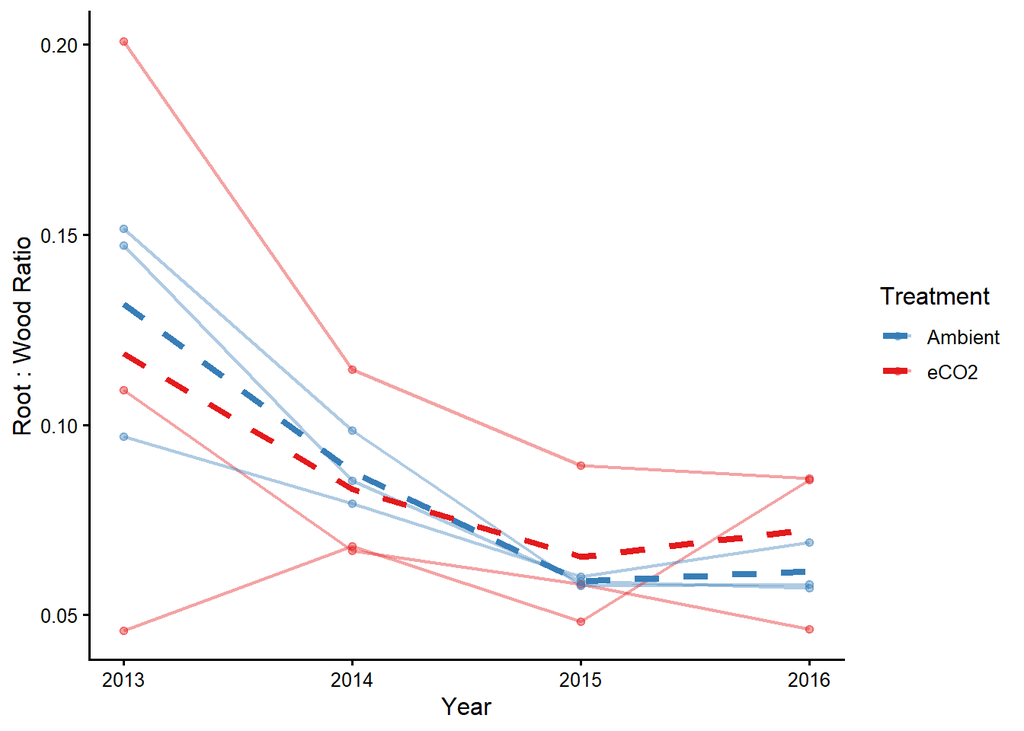

Figure 3: Root:Wood Allocation Ratio. The high variability in the faint lines (individual rings) suggests that allocation strategies are driven more by local conditions than by the global CO2 treatment.

```r
ggplot(df %>% filter(!is.na(Root_Shoot_Ratio)), aes(x = Year, y = Root_Shoot_Ratio, color = Trt)) +
  geom_line(aes(group = Ring), alpha = 0.4, linewidth = 0.8) +
  geom_point(aes(group = Ring), alpha = 0.4) +
  stat_summary(aes(group = Trt), fun = mean, geom = "line",
               linewidth = 1.5, linetype = "dashed") +
  scale_color_manual(name="Treatment", values = cols) +
  scale_x_continuous(breaks = 2013:2016) +
  labs(y = "Root : Wood Ratio", x = "Year")

# Export the graph for presentation
ggsave(here("EucFACE_P_Analysis/output", "Fig3_Root_Allocation.png"),
       width = 8, height = 5, dpi = 300)
```

```r
lm_ring <- lm(Root_Shoot_Ratio ~ Ring + as.factor(Year), data = df)
print_stats(lm_ring, "ANOVA: Effect of Individual Rings on Allocation")
```

Table 3: ANOVA: Effect of Individual Rings on Allocation.

ANOVA: Effect of Individual Rings on Allocation

|  | Df | Sum Sq | Mean Sq | F-Statistic | P-Value | Sig |
| --- | --- | --- | --- | --- | --- | --- |
| Ring | 5 | 0.01 | 0 | 3.04 | 0.043 | * |
| as.factor(Year) | 3 | 0.01 | 0 | 8.19 | 0.002 | * |
| Residuals | 15 | 0.01 | 0 | NA | NA |  |

Note:  
* Indicates statistical significance (P < 0.05).

## 4.2 Functional Efficiency (PUE)

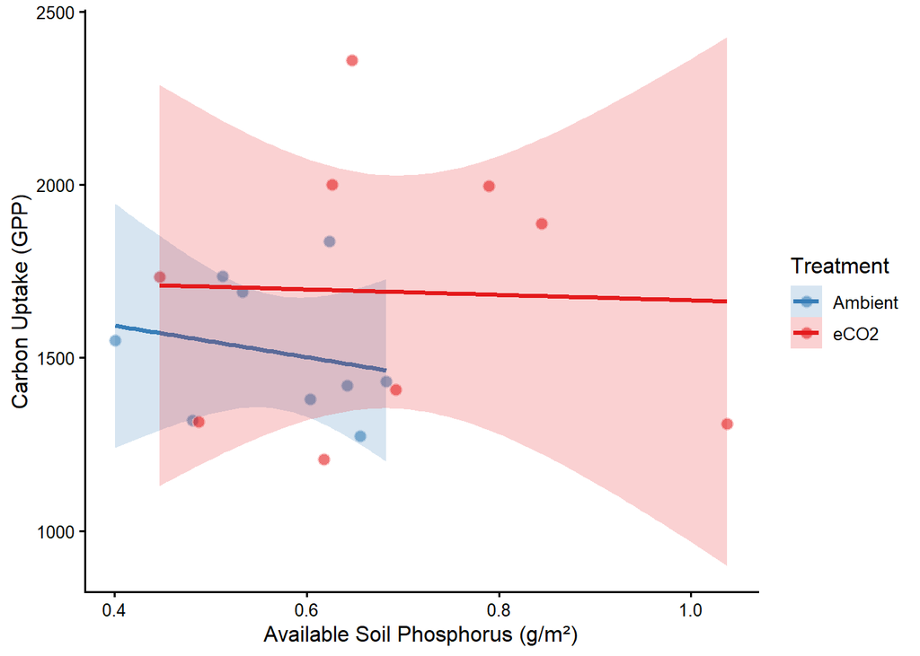

Figure 4: Functional Plasticity (PUE). eCO2 trees trend towards higher productivity per unit Soil P.

```r
df_flux <- df %>% filter(!is.na(PUE) & !is.na(Soil_P))

ggplot(df_flux, aes(x=Soil_P, y=GPP, color=Trt, fill=Trt)) +
  geom_point(size=3, alpha=0.6, shape=21, color="white") +
  geom_smooth(method="lm", alpha=0.2) +
  scale_color_manual(name="Treatment", values=cols) +
  scale_fill_manual(name="Treatment", values=cols) +
  labs(x="Available Soil Phosphorus (g/m²)", y="Carbon Uptake (GPP)")

# Export the graph for presentation
ggsave(here("EucFACE_P_Analysis/output", "Fig4_Functional_Efficiency.png"),
       width = 8, height = 5, dpi = 300)
```

```r
m_pue <- lmer(GPP ~ Soil_P * Trt + (1|Ring), data=df_flux)
print_stats(m_pue, "ANOVA: PUE Interaction")
```

Table 4: ANOVA: PUE Interaction (Soil P x Treatment).

ANOVA: PUE Interaction

|  | Sum Sq | Mean Sq | NumDF | DenDF | F-Statistic | P-Value | Sig |
| --- | --- | --- | --- | --- | --- | --- | --- |
| Soil_P | 98803.23 | 98803.23 | 1 | 13.6 | 1.87 | 0.193 |  |
| Trt | 1357.46 | 1357.46 | 1 | 14.0 | 0.03 | 0.875 |  |
| Soil_P:Trt | 13004.88 | 13004.88 | 1 | 13.6 | 0.25 | 0.627 |  |

Note:  
* Indicates statistical significance (P < 0.05).

**Observation:** In Figure 4, the eCO2 regression line (Red) sits visually higher than the Ambient line (Blue), which would imply higher Carbon uptake (GPP) for a given amount of Soil P.

**Analysis:** However, statistical testing in Table 4 does not support this visual trend. Both the main Treatment effect (P=0.875) and the Interaction term (P=0.627) are non-significant. We conclude that while there may be a biological tendency toward efficiency, the high variability (noise) in the ecosystem prevents a definitive confirmation of **Functional Plasticity** in this dataset.

# 5 Conclusion

Interestingly, the forest is not entirely passive. We observed high variability in root allocation strategies (Figure 3) driven by local conditions (Ring effects), and a visual trend suggesting trees under eCO2 attempt to operate at higher phosphorus use efficiency (Figure 4).